# Part I: Decisions, distributions, data

Predictions: Theory and Practice

# Optimal Predictions

### Example: Good Judgement

- Good judgement [(link)](https://www.gjopen.com/challenges)
  - webpage gathering (and selling) predictions
  - awarding the title of “superforecasters” (top 2%)
- The Economist 2023: “The Good Judgment team […] correctly forecasting the outcomes of eight questions…”
  - Global growth was 3%
  - China grew by 5%
  - ruling-party candidates won in Nigeria and Turkey
  - Vladimir Putin was not ousted
  - there was no election in Britain
  - no clash over Taiwan
  - no nuclear device detonated by Russia

### Current Topics on Good Judgement Open (2026)

- **Global Armed Conflict**
  - Will Mojtaba Khamenei flee Iran or cease to be its supreme leader before Sep 2026?
- **Artificial Intelligence**
  - What will be the AI model adoption rate for large US businesses in Dec 2026?
  - What will be NVIDIA’s total revenue in Q1 of fiscal year 2027?
- **The Economist: World Ahead 2026** (20 questions)
  - Will the FDA approve Moderna’s mRNA flu vaccine before Oct 2026?
  - India’s real GDP growth (2026-27)
  - Effective US tariff rate for all imports in H2 2026
- **“Right!” said FRED**
  - Spread between 10-year and 2-year Treasury yields
  - 30-year fixed mortgage rate for week ending 25 June 2026
  - unemployment rate for June 2026

### Goals

By the end of this lecture, you should be able to answer:

1. What are the main **types** of prediction targets?
2. When is a prediction **accurate**?
3. When is a prediction **calibrated**?
4. When is a prediction **sharp**?
5. In which sense is calibration **optimal**?

### Mathematics motiviation for everyone

- this lecture is very mathematical
- my take on mathematics:
  - mostly about developing **intuition that is government by logic**
  - two step procedure:
    1. intuition: “A seems true.”
    2. mathematics: “Check A, if true proceed, otherwise revise intuition.”
  - developing this intuition requires exposure
  - LLMs can handle math for you, but often struggle with transfer to applications
- we will revisit the concepts when empirically analyzing predictions and human behavior

## Types of predictions

### Targets of predictions

- the three most important targets of predictions are
  - binary events
    - $\{0,1\}$
    - TRUE,FALSE
    - event $E$, complement $E^C$
    - examples: $\{rain, no rain\}$, {higher, not higher}
  - categorical variables
    - $\{E_1,E_2,\dots,E_k\}$
    - examples: countries, $\{rock, paper, scissors\}$, {higher, same, lower},…
  - real-valued (continuous) variables
    - $y \in \mathbb{R}$
    - can be decomposed into infinite number of events ($y \le c$)
    - examples: money values, length, weight, …
- we start with **binary events**
  - categorical and real-valued can be reduced to event predictions
  - later concepts will be generalized to real-valued prediction targets

### Necessary knowledge

- a random variable $y$
  - maps into the space of **possible outcomes**
  - example (coin toss): maps into {“heads”,“tails”}
  - takes on one **realized value** (also “realization”)
- distribution of a random variable
  - distribution over the possible outcomes
  - example (coin toss): P(“head”) = 50%, P(“tails”) = 50%
- Sidenote: not necessary are the concepts of
  - measureability of a random variable
  - $\sigma$-algebras as a concept for information sets
- for a real-valued random variable $y$…
  - possible outcomes are numbers
  - example (coin toss): with “heads” = 1, “tails” = 0
- … the **expectation** or **expected value** $E[y]$
  - is a real number.
  - is a property of the distribution, not of the realized value
- example (coin toss):
  - possible outcomes: “heads” = 1, “tails” = 0
  - distribution / probabilities: $P("0")=P("1")=50\%=0.5$
  - Expected value
    $$E[y]= 0 \times P("0") + 1 \times P("1") = 0 \times 0.5 + 1 \times 0.5=0.5$$

## Point (deterministic) predictions

**CautionDefinition: point predictions.**

A prediction $\hat y$ for an event is a point prediction if it is an element of the potential outcomes $\{0,1\}$.

- no direct connection to decision-making
  - remember: Decisions are informed by probabilities

## Probabilistic predictions

**CautionDefinition: probabilistic predictions.**

The prediction $\hat p$ is called probabilistic if it is a **probability distribution** over the elements $\{0,1\}$.

- distribution over $\{0,1\}$ identified by $p=P(1)$
  - follows that $P(0) = 1 - p$

### What is a good prediction (in hindsight)?

- easy, if y = 1 then
  - $\hat y=1$ is better than $\hat y = 0$
  - $\hat p=1$ is better than any $\hat p < 1$
- but this is **ex-post** (in hindsight)
- How does a **good prediction** look like in general?
  - before the uncertainty around the target $y$ is resolved
  - we need a more technical framework to handle this question!

## The prediction space setting

- technically we understand the prediction target $y$ and the prediction $\hat y$ or $\hat p$ as **random variables**
  - this is called the **prediction space setting** [@gneiting2014probabilistic]
  - we judge the performance of a prediction via the relation between the random variables
- what would be good properties for a prediction?
  - perfect $\hat y = y$ (often unrealistic)
  - unbiased $E[\hat y - y] = 0$ (classic property)
  - error $e= y-\hat p$ should be small (note: $e$ is also a random variable)
    - e.g., mean absolute error $E[|e|]$ small

### Notation summary

- uncertain outcome $y$
- its (unknown) distribution $p$
  - we write $E_{y\sim p}[f(y)]$ or shorter $E_p[f(y)]$
  - $E[f(y)]$ normally means $E_{y\sim p}[f(y)]$
- a (point) prediction $\hat y$
- a probability prediction $\hat p$
- Example:
  - $y$ is income increasing next year.
  - $\hat y$ could be “Yes”.
  - $\hat p= 0.8 = 80\%$.

### Toy example

- Let’s consider a toy example: Target $y \sim Bernoulli(0.5)$

**R**

```r
# a random sample from the Bernoulli distribution
set.seed(1)
rbinom(n = 10, p = 0.5, size = 1)
```

```
 [1] 0 0 1 1 0 1 1 1 1 0
```

**Python**

```python
import numpy as np
rng = np.random.default_rng(seed=1)
rng.binomial(n=1, p=0.5, size=10)
# [0, 0, 0, 1, 1, 0, 1, 1, 1, 1]
```

- perfect prediction $\hat p = y$
- unbiased prediction $\hat p = 0.5$
- biased prediction $\hat p=0.6$
- unbiased prediction with noise $\hat p \sim U[0,1]$ (and independent of $y$)
- unbiased prediction with maximum noise $\hat p = 1-y$ (depends on $y$)

### The prediction space setting illustrated

- Next we discuss two scenarios for which the prediction space setting is appropriate:
  1. **sampling predictions from data** — $\hat p$ varies because data varies
  2. **sampling from a population of prediction problems** — $\hat p$ varies across different forecasters or events
  - in which sense is prediction $\hat p$ a random variable?

### … sampling predictions from data

- one approach to predict an event $y$:
  - take a sample of data $(y_1,\dots,y_n)$
  - compute **sample average** $\hat p = \frac 1 n \sum_{i=1}^n y_i$
- if(!) data is **randomly sampled** from $p$, the prediction $\hat p$
  - is unbiased
  - increases in accuracy with sample size $n$
- “sampling uncertainty”: $\hat p$ is a random variable as a function of random data

### … sampling from prediction problems

- there is another way to interpret the prediction space setting
- consider a population of prediction problems, where each draw consists of the pair (target outcome, prediction)
  $$(y,\hat y) \text{ or } (y,\hat p)$$
- Example: All the predictions generated from the CIA
  - our sample consists of all the recorded predictions
  - one observation might look like
    - Event: Does Russia annex Crimea in 2014?
    - prediction: “No” or “5%”
  - In the prediction space setting we can answer questions like
    - which expert in the CIA is doing best
    - what systemic mistakes can be detected from the data
    - how can we improve a raw prediction

### Example: Yourself

- try to write down (subconscious) beliefs as predictions
- example targets
  - I will finish this project until xx.xx.xxxx. (too optimistic?)
  - Will I enjoy working on an exercise with a random student from this class? (too pessimistic?)
  - Next week, I will start to do xxx. (“planning you” more disciplined than “implementing you”?)

[figure not shown]

### Conditional expectation: a reminder

- …**conditional expectation** given $x=c$,
  $$E[y|x=c]$$
  - expected value with respect to conditional distribution $P(y|x=c)$
  - known with Bayes rule
  - is a real number
- …**conditional expectation**,
  $$E[y|x]$$
  - is a function of $x$
  - is a random variable
- Rules for the conditional expectation
  - linear
    $$E[y_1 + y_2 | x] = E[y_1 | x] + E[y_2 | x]$$
    $$E[c y | x]=cE[y|x]\text{ for } c \text{ constant}$$
  - tower property
    $$E[E[y|x]] = E[y]$$
    - *averaging a conditional expectation over all conditions gives back the unconditional expectation — double averaging collapses to single averaging*
  - or more general
    $$E[E[y|\color{red}{x_1},\color{blue}{x_2}]|\color{blue}{x_2}] = E[y|\color{red}{x_1}]$$
  - Functions $f$ of conditioning information are constant:
    $$E[f(x)|x]=f(x)$$
    $$E[f(x)y|x]=f(x)E[y|x]$$
  - if $y$ and $x$ independent, then
    $$E[y|x] = E[y]$$

## Calibration

**CautionDefinition: Calibration**

A prediction $\hat p$ is **calibrated** for $y$ if
$$E(y | \hat p) = \hat p.$$

### Calibration vs. Unbiasedness

- **Unbiasedness**: a *global* (marginal) condition on the average prediction
  $$E[y] =E[\hat p]$$
- **Calibration**: a *local* (conditional) condition for every value of $\hat p$:
  $$E[y|\hat p] = \hat p$$

**Calibration implies unbiasedness, but not vice versa.**

- Calibration $\Rightarrow$ unbiasedness: by the tower property
  $$E[y] = E[E[y|\hat p]] = E[\hat p]$$
- Unbiasedness $\not\Rightarrow$ calibration — counterexample:
  - $y \sim Bernoulli(0.5)$, $\hat p \sim U[0,1]$ independent of $y$
  - Unbiased: $E[\hat p] = 0.5 = E[y]$ ✓
  - Not calibrated: $E[y|\hat p] = 0.5 \neq \hat p$ for most values of $\hat p$ ✗
- One example of a calibrated prediction is the random sample predictor
  - assume we can sample from similar events (e.g., “does webpage visitor buy item A”)
  - predict next visitor with **sample average**
    $$\hat p = \frac 1 n \sum_{i=1}^{n} y_i$$
  - this prediction is calibrated

### Proof (handwritten in lecture):

**Tiprandom sample predictor**

If $y_i \sim_{iid} p$ then $\hat p = \frac 1 n \sum_{i=1}^{n} y_i$ is a calibrated prediction for $y_{n+1}$.

- Proof:

$$\begin{align*}
E[ y -\hat p| \hat p, p] =& E[ y - \frac 1 n \sum_{i=1}^{n} y_i| \hat p,p] \\
=&E[ y|\hat p , p ] - E[\frac 1 n \sum_{i=1}^{n} y_i| \hat p,p] = p - \frac 1 n np=0
\end{align*}$$

and thus
$$E[ y -\hat p| \hat p] = E[ \underbrace{E[y -\hat p| \hat p,p]}_\text{=0} | \hat p] = 0$$

### Calibration curve

- We can understand calibration as a property of the **calibration curve** defined by the conditional expectation function
  $$f(\hat p) = E[y|\hat p].$$

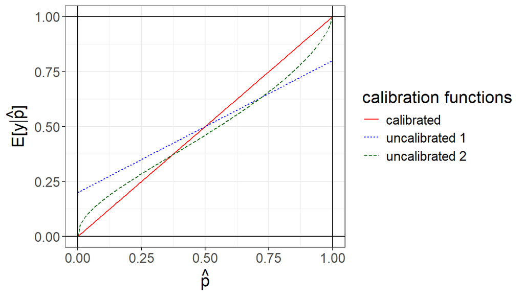

```r
library(latex2exp)
library(ggplot2)
ggplot()+
  geom_function(fun=identity,col="red",aes(linetype = "calibrated"))+
  geom_function(fun=function(x) x*0.6+0.2,col="blue",aes(linetype = "uncalibrated 1")) +
  geom_function(fun=function(x) exp(- (-log(x))^0.7),col="darkgreen",aes(linetype = "uncalibrated 2")) +
  scale_linetype_discrete(name = "calibration functions")+
  xlab(label = TeX("$\\hat{p}$"))+
  ylab(label = TeX("$E[y|\\hat{p}]$"))+
  geom_vline(xintercept = c(0,1))+
  geom_hline(yintercept = c(0,1))
```

Figure 1: Some calibration curves. The red line is calibrated with $f(\hat p)=\hat p$.

### Summary: Calibration

- A prediction is **calibrated** if
  $$E(y | \hat p) = \hat p.$$
- The ratio of events happening in a **random sample** is a calibrated prediction
- The **calibration curve** explains deviations from calibration
- Open question: How does calibration relate to **decision-making**?

## Accuracy

- consider the situation with two predictions (e.g., two experts) for the same event
  - who is the better prediction expert?
- if you know your decision problem, the best expert maximizes your utility
  - based on a prediciton $\hat p$ you take the action that maximizes your expected utility
    $$a^\star(\hat p) = arg max_a E_{y\sim\hat p}[u(a,y)]$$
  - so the better expert leads to higher expected utilies
    $$U(\hat p) = E[u(a^\star(\hat p),y)]$$
  - the highest expected utility can be achieved if $\hat p = p$ where $p$ is the actual distribution of $y$

### Proper scoring rules

- there are also generic functions $s(\hat p, y)$ with the property that their **expected utility** is **maximized at the true distribution** of $y$

**CautionDefinition: Proper scoring rule.**

A function $s(p,y)$ is called a **scoring rule**.

A scoring rule is called **proper** if $f(\hat p)=E[s(\hat p,y)]$ has a maximum at $\hat p = p$.

- sidenotes:
  - Sometimes difference between proper and *strictly* proper
  - Sometimes oriented differently such that proper means minimizing expected score (“loss function”)

### Quadratic scoring rule

- the most famous proper scoring rule is the **quadratic scoring rule** (also called **Brier score**)

**CautionDefinition: The quadratic scoring rule.**

$$s_{qsr}(\hat p, y) = 1-(\hat p - y)^2$$

- The quadrtic scoring rule
  $$s_{qsr}(\hat p, y) = 1-(\hat p - y)^2$$
  is equivalent to
  $$s_{qsr}(\hat p, y) = 2\hat p_y - \hat p^2 - (1-\hat p)^2$$
  where $\hat p_y=\hat p$ if $y=1$ and otherwise $\hat p_y = (1-\hat p)$
  - the first term $2 \hat p_y$ rewards probability put on the true event
  - the second term penalizes putting mass on the extremes

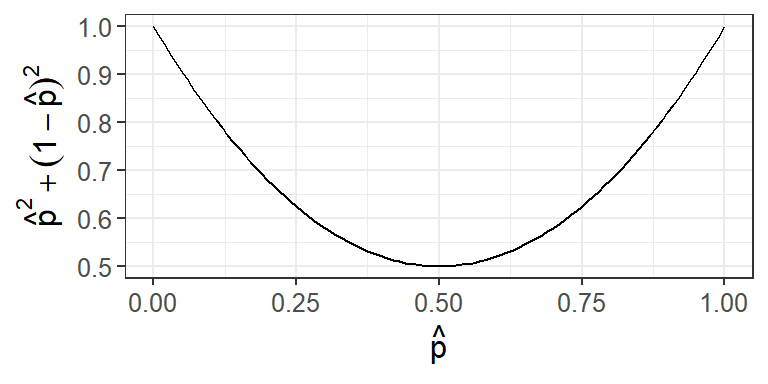

  ```r
  library(ggplot2)
  library(latex2exp)

  ggplot()+
    geom_function(fun=function(x) x^2+(1-x)^2)+
    xlab(TeX("$\\hat{p}$"))+
    ylab(TeX("$\\hat{p}^2 + (1-\\hat{p})^2$"))+
    theme(text = element_text(size=12))
  ```

### Proof (handwritten in lecture):

### The QSR is proper

**TipProof: The QRS is proper.**

Look at the FOC of $E[s_{qsr}(\hat p ,y)]$ to find optimal $\hat p$

$$\partial \hat p E[ s_{qsr}(\hat p, y)]= E[\partial \hat p s_{qsr}(\hat p, y)]=E[ -2 (\hat p- y)]=-2 (\hat p - E[y])$$
and
$$\partial \hat p E[ s_{qsr}(\hat p, y)]=0 \iff \hat p = E[y]$$
Thus, the expectation is maximized if true propability of $y$ is issued as prediction, i.e., the quadratic scoring rule is proper.

(Using: $E[y]=p \times 1 + (1-p) \times 0=p$.)

### What is wrong with a linear score?

- the most intuitive idea would be to consider scores

$$s_l(\hat p, y) = |y-\hat p|$$

The expected score is:

$$\mathbb{E}[s(\hat{p}, y)] = p \cdot |1 - \hat{p}| + (1 - p) \cdot |\hat{p} - 0| = p(1 - \hat{p}) + (1 - p)\hat{p}$$

Simplifying:

$$\mathbb{E}[s(\hat{p}, y)] = p - p\hat{p} + \hat{p} - p\hat{p} = p - 2p\hat{p} + \hat{p}$$

Taking the derivative with respect to $\hat{p}$:

$$\frac{d}{d\hat{p}} \mathbb{E}[s(\hat{p}, y)] = -2p + 1$$

This derivative is constant in $\hat{p}$, indicating that the expected score is linear in $\hat{p}$:

(If $p = \frac{1}{2}$, the expected score is constant, so any $\hat{p} \in [0,1]$ minimizes the score.)

- Thus, the linear score is not proper. It incentivizes to report the event with the higher probability (a point prediction).

### The logarithmic score

- another widely used proper scoring rule is the **logarithmic scoring rule** (also called **log score**)

**CautionDefinition: The logarithmic scoring rule.**

$$s_{log}(\hat p, y) = log(\hat p_y),$$
where $\hat p_y$ is probability mass of $\hat p$ at the realized target value $y$, i.e. $\hat p_1=\hat p$ and $\hat p_0=1-\hat p$.

- It is no coincidence that you know the quadratic score/loss from OLS and the logarithmic score from Maximum Likelihood estimation.

### Summary: Accuracy

- How do we compare two predictions (experts or systems)?
  - If we have a decision and a utility we use the expected utility
    $$U(\hat p)=E[u(a^\star(\hat p),y)]$$
  - If we do not have the specifics, we can use proper scoring rules
    $$S(\hat p) = E[s(\hat p,y)]$$
- We can call a prediction $\hat p_A$ **more accurate than** $\hat p_B$ if
  $$S(\hat p_A) > S(\hat p_B)$$
- One proper scoring rule is the quadratic scoring rule
  $$s_{qsr}(\hat p, y) = 1-(y-\hat p)^2$$

## Sharpness

- sharpness describes the concentration of a probabilistic prediction
  - not applicable to point predictions (or point predictions are the sharpest of predictions)
- sharpness is a property of the prediction alone
  - not of prediction and target
- Sometimes also referred to as “boldness”

### The variance of a distribution

- You already know **the variance** of $\hat p$ as **measure of sharpness**
- the variance of a distribution is defined as
  $$var(p)=E_p[(y-E_p[y])^2]$$
- For a probability $p$ for an event this is
  $$var(p) = p (1-p)^2 + (1- p) p^2
  = p(1-p) [(1-p)+p]= p (1-p)$$
- For a prediction $\hat p$, we rescale and define
  $$\text{sharpness}(\hat p)=1-4 var(\hat p)$$

### Illustrating sharpness

$$\text{sharpness}(\hat p)=1-4 var(\hat p)$$

- High sharpness means the predictions are close to 0 or 1, indicating strong confidence in the outcome.
- Low sharpness means predictions are closer to 0.5, showing less confidence and more uncertainty.

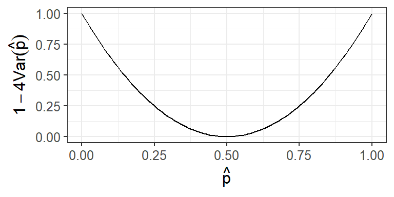

```r
library(ggplot2)
library(latex2exp)

ggplot()+
  geom_function(fun=function(p)1+4*(-p)*(1-p))+
  xlab(TeX("$\\hat{p}$"))+
  ylab(TeX("$1-4Var(\\hat{p})$"))+
  theme(text = element_text(size=12))
```

### Expected score and variance

- Sharpness can be interpreted in terms of scores and utilities
- Consider the expected score under probability $p$
  $$S(p)=E_p[s(p,y)]$$
  where $E_p$ means the expectation assuming $y\sim p$.
- If score $s$ is derived from decision and utility, then
  $$S(p) = \text{ expected utility under uncertainty } p$$
- for the QSR:
  $$\begin{align*}
  S_{qsr}(p)&=E_p[s_{sqr}(p,y)]\\
  &=1 - p (1-p)^2+(1-p)p^2\\
  &=1 - p(1-p) [(1-p)+p]= \\
  &=1 - var(p)
  \end{align*}$$

### Toy example revisited

| prediction | Miscalibration function $\|E[y\|\hat p]-\hat p\|$ | expected score $E[s_{qsr}(\hat p,y)]$ | Sharpness $1-4Var(\hat p)$ |
| --- | --- | --- | --- |
| $\hat p = y$ | $0$ | $1$ | $1$ |
| $\hat p = 0.5$ | $0$ | $0.75$ | $0$ |
| $\hat p = 0.6$ | $0.1$ | $0.74$ | $0.04$ |
| $\hat p \sim Bern(0.5)$ | $0.5$ | $0.5$ | $1$ |

*Note: $\hat p \sim Bern(0.5)$ achieves maximum sharpness (1) because it only takes the extreme values 0 and 1 — yet it is badly miscalibrated because it is independent of $y$. Sharpness alone is not enough.*

### Sidenote: Entropy

- if we take the negative expected score with respect to the **logarithmic scoring** rule $s_{log}(p,y)=log(p_y)$ we get the **entropy**
- an information measure describing **randomness** or **uncertainty**
  - the average amount of information required to describe the outcome of a random event
  - measured in bits
- also a physical concept describing the **disorder** of a system
  - governed by the “second law of thermodynamics”
  - total entropy of an isolated system tends to increase over time

## Optimal: Sharpness subject to calibration

In summary:

- Sharpness = Concentration of predictions (confidence level)
- Calibration = Agreement between predictions and actual outcomes

Good probabilistic forecasts aim to be both sharp and well-calibrated.

### Decomposition of accuracy

- The performance of a prediction in terms of a scoring rule can be decomposed into three parts
  - define $p_C = E[y|\hat p]$ a calibrated version of $\hat p$
  - define $p_R = E[y]$ a constant calibrated prediction (contains no information)
  - define $S(\hat p)=E[s(\hat p,y)]$
- Then the expected score is
  $$\begin{align*}
  S(\hat p) &= S(p_R) + [S(p_C) - S(p_R)] - [S(p_C) - S(\hat p)] \\
  &= \underbrace{S(p_R)}_{\text{UNC}} + \underbrace{[S(p_C) - S(p_R)]}_{\text{DSC}} - \underbrace{[S(p_C) - S(\hat p)]}_{\text{MSC}},
  \end{align*}$$
- UNC (uncertainty): score from uncertainty in outcome
- DSC (discrimination ability): score improvement by prediction
- MSC (miscalibration): score loss because prediction is miscalibrated
- Then the expected score is

$$\begin{align*}
S(\hat p) = \text{UNC} + \text{DSC} - \text{MSC},
\end{align*}$$

- We want MSC to be small (ideally $\text{MSC}=0$) and DSC large
- When is DSC large?
  - if $\hat p$ far away from $p_r=E[y]$, i.e. if $\hat p$ is bold/sharp.
- In this sense, we want to maximize sharpness subject to calibration.

## ideal predictions and information

- Another way to look at this is via information/input variables
- let’s say $x$ denotes all the information necessary to predict $y$ perfectly
  - some part of $x$ is known to the forecaster, $x_k$
  - the remainder, say $x_u$, is unknown to the forecaster
  - we have $x=(x_k,x_u)$
- the prediction is a function of the known information
  - $\hat p=f(x_k)$

**CautionThe conditional expectation is optimal.**

Among all functions of $x_k$, the conditional expectation
$$\hat p = E[y|x_k]$$
maximizes any expected proper score $E[s(\hat p,y)]$ [@holzmann2014role]

- $E[y|x_k]$ is also called the **ideal prediction** for information $x_k$

**CautionIdeal implies calibrated.**

All ideal predictions are calibrated.

- Proof:
  $$E[y- E[y|x_k] | \hat p]= E[y|\hat p] - E[ E[y|x_k]|\hat p] = 0$$
  (as $E[ E[y|x_k]|\hat p]=E[y|\hat p]$ because $\hat p = f(x_k)$)